# Final Project

Josey Schanen

21 May, 2020

# Packages and Data

```r
setwd("C:/Users/Barrie/Desktop/NCGraphing")
library(tidyverse)
cbbPalette <- c("#000000","#E69F00","#56B4E9","#009E73","#F0E442","#0072B2","#D55E00","#CC79A7")
```

```r
str(intensity)
intensity2 <- read.csv("AgriculturalEmissionsIntensity2.csv")
str(intensity2)
emisstype <- read.csv("AgriculturalEmissionsType.csv")
str(emisstype)
```

# Graphs I

This graph is an evaluation of the emissions footprints of foods that we consider major staples of our diet have. The intent I had in this was to point out the extent to which our dietary habits contribute to global climate change. This should make us consider what choices we ought to make individually, as well as how we ought to incentivize production of goods with a lower emissions footprint. The appropriate format for this is a bar graph considering that it is making comparisons between categorical data. This data indicates that the consumption of plant staples directly is considerably less emissions-intensive than the consumption of animal products, and especially beef. In fact, beef had such a high rate of kilograms of carbon dioxide equivalent per kilograms of product that I felt compelled to make a second graph to depict the differences in the other products. I wasn’t surprised that beef was the most emissions intensive, but the extent was surprising nonetheless. I have since deducted that the reasoning for this is that this is measuring carbon dioxide EQUIVALENT emissions, not just carbon dioxide itself. This means that it is also factoring in the carbon dioxide equivalent of methane (CH4) and nitrous oxide (NO2) emissions, and beef as it is currently raised contributes a huge amount of methane and significant amounts of nitrous oxide. What I am still perplexed about is why milk and beef don’t have similar emissions intensity. These greenhouse gases have a considerably higher greenhouse effect than carbon dioxide. However, there is also nuance that we ought to consider in these graphs. First and foremost, while methane is a very potent greenhouse gas it also dissipates from the atmosphere considerably sooner than carbon dioxide. Additionally, while the industrialized model of raising these products is ecologically unsustainable, there are regenerative forms of agriculture that exist that can enhance the ecological commons. Whereas industrially raised beef has the worst emissions footprint, beef cattle mob-stocked and moved on pasture is ecologically enhancing and sequesters more carbon than it emits. This data is useful, but it certainly doesn’t give the whole picture.

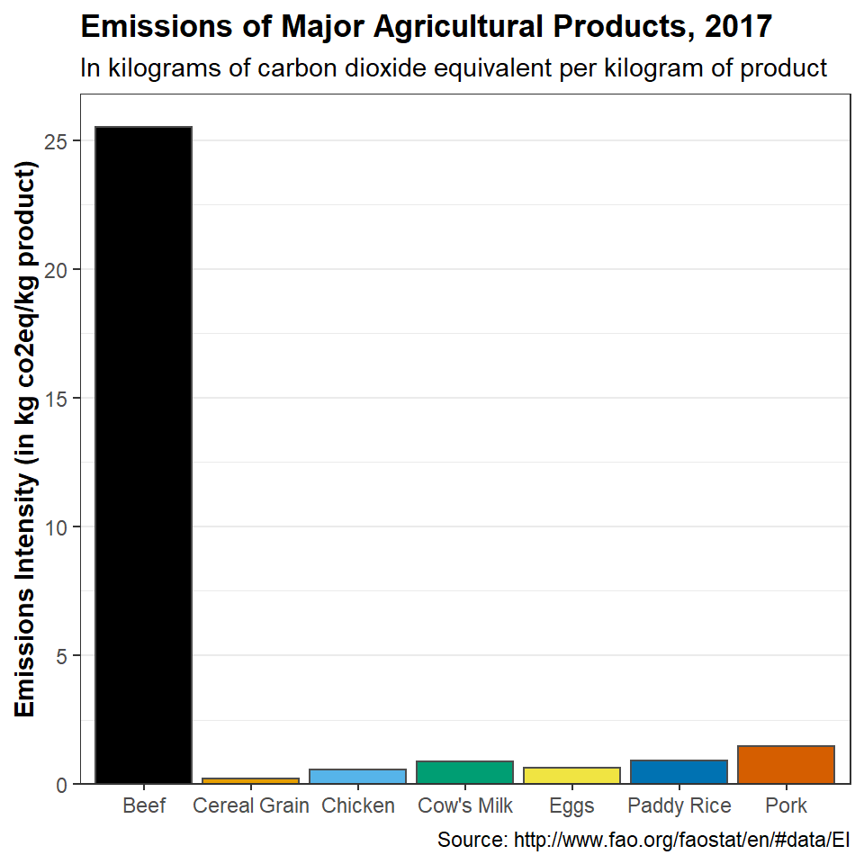

```r
ggplot(data=intensity,mapping=aes(x=Item,y=Value,fill=Item)) +
  geom_bar(stat="identity",color="gray30") +
  scale_x_discrete(name="Product") +
  scale_y_continuous(name="Emissions Intensity (in kg co2eq/kg product)",expand=expansion(mult=c(0,0.05))) +
  scale_fill_manual(values=cbbPalette) +
  theme_bw() +
  theme(plot.title=element_text(face="bold"),axis.title.x=element_blank(),axis.title.y=element_text(face="bold"),panel.grid.major.x=element_blank(),panel.grid.minor.x=element_blank(),
        legend.position="none") +
  labs(title="Emissions of Major Agricultural Products, 2017",subtitle="In kilograms of carbon dioxide equivalent per kilogram of product",
       caption="Source: http://www.fao.org/faostat/en/#data/EI")
```

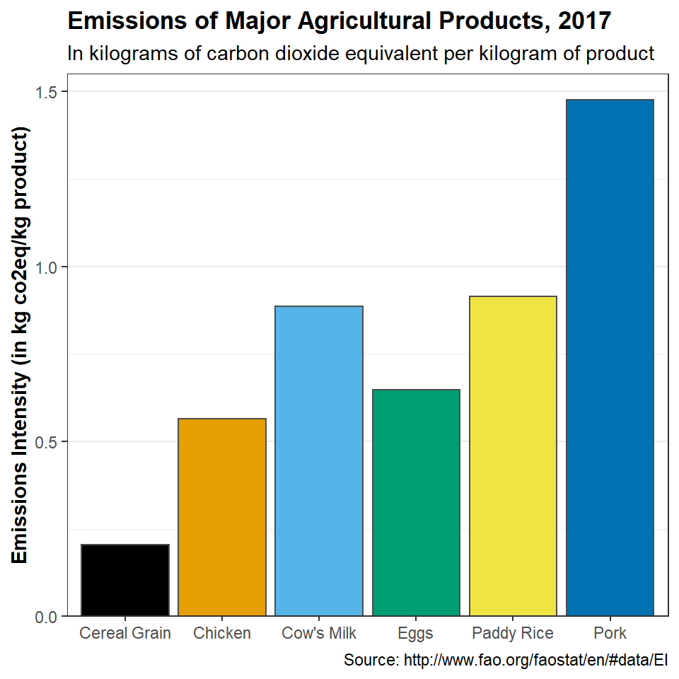

```r
ggplot(data=intensity2,mapping=aes(x=Item,y=Value,fill=Item)) +
  geom_bar(stat="identity",color="gray30") +
  scale_x_discrete(name="Product") +
  scale_y_continuous(name="Emissions Intensity (in kg co2eq/kg product)",expand=expansion(mult=c(0,0.05))) +
  scale_fill_manual(values=cbbPalette) +
  theme_bw() +
  theme() +
  theme(plot.title=element_text(face="bold"),axis.title.x=element_blank(),axis.title.y=element_text(face="bold"),panel.grid.major.x=element_blank(),panel.grid.minor.x=element_blank(),
        legend.position="none") +
  labs(title="Emissions of Major Agricultural Products, 2017",subtitle="In kilograms of carbon dioxide equivalent per kilogram of product",
       caption="Source: http://www.fao.org/faostat/en/#data/EI")
```

# Graphs II

This graph is an evaluation of how much different agricultural practices contribute to carbon dioxide equivalent emissions, with an additional component of time to evaluate differences in emissions over each decade. The intention of this graph is to draw attention to how certain practices contribute to emissions disproportionately, and what aspects of farming we ought to address if we are to lower the emissions footprint. Again, this involves a bar graph because it is making comparisons between categorical data. The findings clearly indicate that overall emissions increase, and that enteric fermentation (in other words the digestion of ruminant livestock) contributes the highest proportion of carbon dioxide equivalent emissions. The reason why enteric fermentation has such a significant contribution is because it involves methane (CH4) emissions, which I discussed before, so this is another area where there is some nuance. Some additional factors to consider are that data for tillage is only available from 1997 onwards, and that emissions from synthetic fertilizers surpass emissions from manure management in 1977 and rice cultivation for 1987 (because manure and rice production has increased slowly, whereas synthetic fertilizers have become more rapidly adopted recently). This graph provides some important “food for thought” to how we could make our agricultural system more climate-friendly.

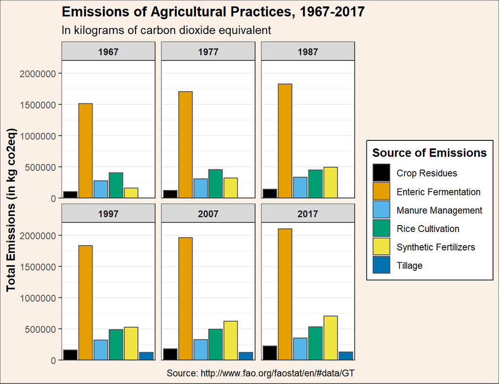

```r
ggplot(data=emisstype,mapping=aes(x=Item,y=Value,fill=Item)) +
  geom_bar(stat="identity",color="gray30") +
  scale_y_continuous(name="Total Emissions (in kg co2eq)",expand=expansion(mult=c(0,0.05))) +
  scale_fill_manual(name="Source of Emissions",values=cbbPalette) +
  labs(title="Emissions of Agricultural Practices, 1967-2017",subtitle="In kilograms of carbon dioxide equivalent",caption="Source: http://www.fao.org/faostat/en/#data/GT") +
  facet_wrap(vars(Year)) +
  theme_bw() +
  theme(plot.background=element_rect(fill="linen",color="gray30"),plot.title=element_text(face="bold"),axis.title.x=element_blank(),axis.title.y=element_text(face="bold"),
        axis.text.x=element_blank(),axis.ticks.x=element_blank(),panel.grid.major.x=element_blank(),panel.grid.minor.x=element_blank(),legend.background=element_rect(color="black"),
        legend.title=element_text(face="bold"),strip.text=element_text(face="bold"))
```